# Peer Assessments - Project 1

This is the Peer Assessment from project 1 of course Reprodutive Research.

The data for this assignment is “Activity monitoring data”. The variables included in this dataset are:

**steps**: Number of steps taking in a 5-minute interval (missing values are coded as NA)

**date**: The date on which the measurement was taken in YYYY-MM-DD format

**interval**: Identifier for the 5-minute interval in which measurement was taken

The dataset is stored in a comma-separated-value (CSV) file and there are a total of 17,568 observations in this dataset.

The following activities are archeive:

## A)Loading and preprocessing the data

```r
setwd("~/projeto MINERACAO DE DADOS/Aula Coursera Data Mining/5 - Reproducible Researsh/Peer Assessments/Peer Assessments 1")
x<-read.csv("activity.csv", header = TRUE, sep = ",", quote = "\"",
            dec = ".", fill = TRUE, comment.char = "",stringsAsFactors = FALSE)
```

## B)What is mean total number of steps taken per day?

### Make a histogram of the total number of steps taken each day

```r
library(dplyr)
```

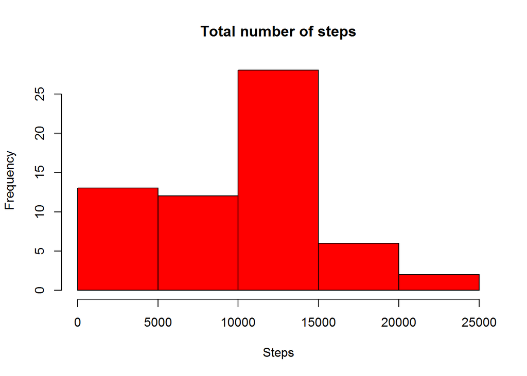

```r
grupo_data<-group_by(x,date)
tot_day<-summarize(grupo_data,total=sum(steps,na.rm=TRUE))
qtd<-tot_day$total
hist(qtd, col="red", main="Total number of steps", xlab="Steps")
```

```r
dev.copy(png,'histogram1.png', width=480, height=480, units="px")
```

```r
dev.off()
```

### Calculate and report the mean and median total number of steps taken per day

```r
mean<-mean(tot_day$total,na.rm=TRUE)
median<-median(tot_day$total,na.rm=TRUE)
```

Mean: 9354.2295082

Median: 10395

## C)What is the average daily activity pattern?

### Time series plot of the 5-minute interval (x-axis) and the average number of steps taken, averaged across all days

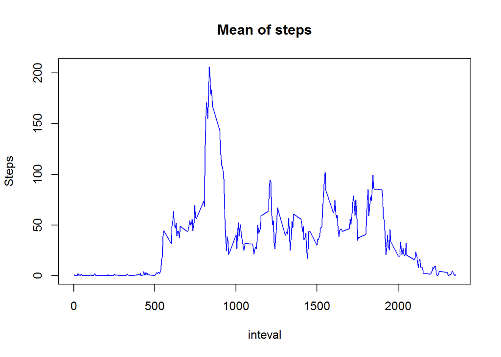

```r
grupo_data<-group_by(x,interval)
tot_interv<-summarize(grupo_data,mean=mean(steps,na.rm=TRUE))

plot(tot_interv$interval,tot_interv$mean,type="l", col="blue",main="Mean of steps", ylab="Steps",xlab="inteval")
```

```r
dev.copy(png,'time_series_plot.png', width=480, height=480, units="px")
```

```r
dev.off()
```

### Which 5-minute interval, on average across all the days in the dataset, contains the maximum number of steps?

```r
max_steps<-max(tot_interv$mean)
five_minutes<-tot_interv[tot_interv$mean==max_steps,1]
```

The maximun number of steps is 206.1698113 and occurs in the 835 interval.

## D) Imputing missing values

### Calculate and report the total number of missing values in the dataset (i.e. the total number of rows with NAs)

```r
missing<-x[is.na(x$steps),]
n_missing<-nrow(missing)
```

The total number of missing values is 2304.

### Create a new dataset that is equal to the original dataset but with the missing data filled in.

```r
complete_data<-merge(x,tot_interv)
complete_data$step2<-ifelse(is.na(complete_data$step),complete_data$mean,complete_data$step)
new_data_set<-complete_data[,c("interval","date","step2")]
names(new_data_set)[3]<-"steps"
new_data_set$datePOSIX<-strptime(new_data_set$date,"%Y-%m-%d")
```

### Make a histogram of the total number of steps taken each day

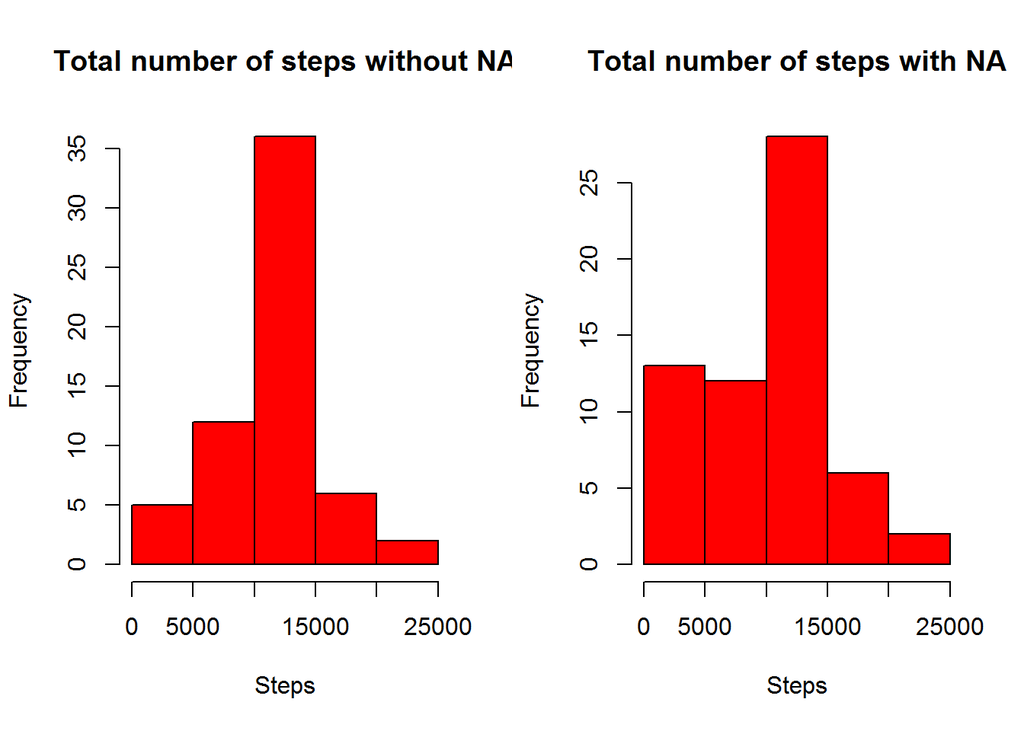

```r
grupo_data2<-group_by(new_data_set[,c("date","steps")],date)
tot_day2<-summarize(grupo_data2,total=sum(steps,na.rm=TRUE))
qtd2<-tot_day2$total

par(mfrow=c(1,2))
hist(qtd2, col="red", main="Total number of steps without NA", xlab="Steps")
hist(qtd, col="red", main="Total number of steps with NA", xlab="Steps")
```

```r
dev.copy(png,'histogram2', width=480, height=480, units="px")
```

```r
dev.off()
```

### Calculate and report the mean and median total number of steps taken per day

```r
mean2<-mean(tot_day2$total,na.rm=TRUE)
median2<-median(tot_day2$total,na.rm=TRUE)
```

Mean with NA: 9354.2295082

Median with NA: 10395

Impact on Mean: 1411.959171

Impact on Median: 371.1886792

## Are there differences in activity patterns between weekdays and weekends?

### Create a new factor variable in the dataset with two levels – “weekday” and “weekend” indicating whether a given date is a weekday or weekend day.

```r
new_data_set$week<-factor(new_data_set$datePOSIX$wday %in% c(0,6),labels=c("weekday","weekend"))
```

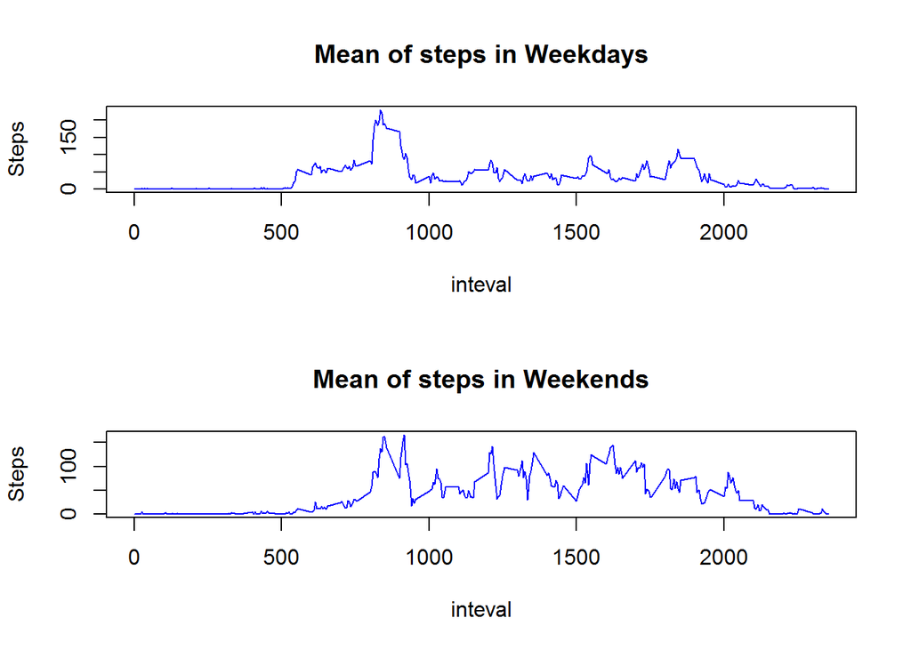

```r
#Select Weekday
WeekdayData<-new_data_set[new_data_set$week=="weekday",]
WeekendData<-new_data_set[new_data_set$week=="weekend",]

grupo<-group_by(WeekdayData[,c("interval","steps")],interval)
WeekdaySteps<-summarize(grupo,mean=mean(steps,na.rm=TRUE))

grupo<-group_by(WeekendData[,c("interval","steps")],interval)
WeekendSteps<-summarize(grupo,mean=mean(steps,na.rm=TRUE))

par(mfrow=c(2,1))

plot(WeekdaySteps$interval,WeekdaySteps$mean,type="l", col="blue",main="Mean of steps in Weekdays", ylab="Steps",xlab="inteval")

plot(WeekendSteps$interval,WeekendSteps$mean,type="l", col="blue",main="Mean of steps in Weekends", ylab="Steps",xlab="inteval")
```

```r
dev.copy(png,'panel_plot.png', width=480, height=480, units="px")
```

```r
dev.off()
```